# Author Classification Using KNN Analysis

## 1. Introduction

In this project, I will be using the K Nearest Neighbour (KNN) classification algorithm to analyse the written works of 2 authors. The written works will analysed using the word choice by author (frequencies of words). Two unknown works will be introduced and the KNN method will be used to predict who the author is, from the two known authors.

The KNN classification algorithm measures the distance between the unknown author's data plots and the know authors data plots and selects the `k` closest points. Where `k` is a constant. The author with most number of points covered within the k-range is the most likely author of the book.

Author 1 is **`L. Frank Baum`** and Author 2 is **`Nathaniel Hawthorne`**. I chose this two authors because of their unique areas of focus. Frank's works focus more on religion, morality and history whiles Nathaniel's works focuses more on children's fantasies.

To read more about the KNN algorithm and how it works, you can visit the [KNN wikipedia page.](https://en.wikipedia.org/wiki/K-nearest_neighbors_algorithm_)

## 2. Extract Dimensions of Analysis from Literary Works

After I parsed the works using a python program I wrote to get all the uniq words in the file and convert it into a csv file of word and word count frequency.

### Import Modules

```python
import pandas as pd
import numpy as np
import matplotlib.pyplot as plt
from IPython.display import display
```

## 3. Pandas Data Exploration

### `a` is Author 1 and `b` is Author 2

Define a function to read csv data from both authors

### Read csv from cs server

All files can be found in the public_html directory of the cs-server - `"https://cs.indstate.edu/~cs40102/authors/" + "{author}.csv"`

```python
# list to be used as column indexes
la = [f'a{i}' for i in range(1,6,1)]
lb = [f'b{i}' for i in range(1,6,1)]

display(la)
display(lb)
```

```
['a1', 'a2', 'a3', 'a4', 'a5']
```

```
['b1', 'b2', 'b3', 'b4', 'b5']
```

Use pandas to read all known csv files and append them into respective lists for both authors

```python
df_a=[]
for i in la:
    i= pd.read_csv("https://cs.indstate.edu/~cs40102/authors/"+f"{i}.csv")
    df_a.append(i)

df_b=[]
for i in lb:
    i= pd.read_csv("https://cs.indstate.edu/~cs40102/authors/"+f"{i}.csv")
    df_b.append(i)
```

Rename all the frequency columns in all the dataframes. This is done so we can merge them into one dataframe

```python
for i in range(len(df_a)):
    df_a[i].rename(columns={"Frequency":f"a{i+1}"}, inplace=True)

for i in range(len(df_b)):
    df_b[i].rename(columns={"Frequency":f"b{i+1}"}, inplace=True)

display(df_a[0].head(),df_b[0].head())
```

|  | Word | a1 |
| --- | --- | --- |
| 0 | a | 0.000024 |
| 1 | abandoned | 0.022587 |
| 2 | abashed | 0.000024 |
| 3 | abided | 0.000024 |
| 4 | able | 0.000024 |

|  | Word | b1 |
| --- | --- | --- |
| 0 | a | 0.000012 |
| 1 | a-wanting | 0.024693 |
| 2 | abandoned | 0.000012 |
| 3 | abased | 0.000012 |
| 4 | abashed | 0.000024 |

### Introduce works of the unknown authors

Once we have our data from the known authors, we introduce the data from the unknown authors `ua` and `ub` and use the `KNN` algorithm to predict who amongst `a` and `b`, is the author.

```python
ua= pd.read_csv("https://cs.indstate.edu/~cs40102/authors/ua.csv").set_index("Word")
display(ua.head())
```

| Word | Frequency |
| --- | --- |
| a | 0.000025 |
| a-bout | 0.020750 |
| abandoned | 0.000050 |
| able | 0.000025 |
| about | 0.000274 |

```python
ub= pd.read_csv("https://cs.indstate.edu/~cs40102/authors/ub.csv").set_index("Word")
display(ub.head())
```

| Word | Frequency |
| --- | --- |
| a | 0.000017 |
| a-courting | 0.021920 |
| a-sobbing | 0.000017 |
| abercrombie | 0.000017 |
| abhorred | 0.000052 |

### Merge each author's works into one dataframe respectively

Author 1's works is now represented in dataframe `a` and Author 2's works is now dataframe `b`

```python
a= df_a[0].merge(df_a[1].merge(df_a[2].merge(df_a[3].merge(df_a[4], how="inner", on="Word"), how="inner", on="Word"), how="inner", on="Word"), how="inner", on="Word")
b= df_b[0].merge(df_b[1].merge(df_b[2].merge(df_b[3].merge(df_b[4], how="inner", on="Word"), how="inner", on="Word"), how="inner", on="Word"), how="inner", on="Word")
# df_a[0]
display(a.head(3))
display(b.head(3))
```

|  | Word | a1 | a2 | a3 | a4 | a5 |
| --- | --- | --- | --- | --- | --- | --- |
| 0 | a | 0.000024 | 0.000025 | 0.000023 | 0.000021 | 0.000024 |
| 1 | able | 0.000024 | 0.000025 | 0.000023 | 0.000021 | 0.000024 |
| 2 | about | 0.000094 | 0.000329 | 0.000046 | 0.000062 | 0.000355 |

|  | Word | b1 | b2 | b3 | b4 | b5 |
| --- | --- | --- | --- | --- | --- | --- |
| 0 | a | 0.000012 | 0.000006 | 0.000009 | 0.000007 | 0.000016 |
| 1 | abide | 0.000012 | 0.000006 | 0.000019 | 0.000013 | 0.000016 |
| 2 | able | 0.000047 | 0.000006 | 0.000009 | 0.000007 | 0.000032 |

## 4. Dimensions of Analysis

I will be using the word frequencies as my dimensions of analysis. Word frequency was calculated as $\frac{unique-word-count}{total-word-count}$. I chose to use frequency because each work has a diferrent total number of words. Using the frequency creates a normalized range of (0-1) for all the works, thus, allowing a comparison between other works.

I will be using 3 dimensions of analysis for this project. That is, 3 words; one representing the `x-axis`, `y-axis` and `z-axis` each. Down in the `Visualization Section`, I will be using these 3 words: `x_word`=`"head"`, `y_word` = `"idea"`, `z_word`=`"looks"`

**NB**: I may change these words to test other words

### Create a single dataframe

Merge both authors works into a single dataframe and set the `Word` as the index

```python
author=a.merge(b, how="inner", on="Word").set_index("Word")
author.loc[:, "a1":"b5"].astype(str).apply(pd.to_numeric)
```

| Word | a1 | a2 | a3 | a4 | a5 | b1 | b2 | b3 | b4 | b5 |
| --- | --- | --- | --- | --- | --- | --- | --- | --- | --- | --- |
| a | 0.000024 | 0.000025 | 0.000023 | 0.000021 | 0.000024 | 0.000012 | 0.000006 | 0.000009 | 0.000007 | 0.000016 |
| able | 0.000024 | 0.000025 | 0.000023 | 0.000021 | 0.000024 | 0.000047 | 0.000006 | 0.000009 | 0.000007 | 0.000032 |
| about | 0.000094 | 0.000329 | 0.000046 | 0.000062 | 0.000355 | 0.000012 | 0.000006 | 0.000009 | 0.000007 | 0.000016 |
| above | 0.000730 | 0.000910 | 0.001334 | 0.001031 | 0.001442 | 0.001046 | 0.000927 | 0.001339 | 0.000962 | 0.000763 |
| accident | 0.000024 | 0.000025 | 0.000023 | 0.000041 | 0.000024 | 0.000012 | 0.000006 | 0.000019 | 0.000007 | 0.000048 |
| ... | ... | ... | ... | ... | ... | ... | ... | ... | ... | ... |
| yet | 0.000518 | 0.000076 | 0.000023 | 0.000701 | 0.000095 | 0.000035 | 0.000006 | 0.000009 | 0.000087 | 0.000111 |
| you | 0.000424 | 0.000025 | 0.000828 | 0.000021 | 0.000024 | 0.000012 | 0.000006 | 0.000009 | 0.000013 | 0.000048 |
| young | 0.010764 | 0.000076 | 0.000161 | 0.000103 | 0.000095 | 0.001716 | 0.003161 | 0.005131 | 0.002711 | 0.008141 |
| your | 0.000188 | 0.000025 | 0.000023 | 0.000021 | 0.000024 | 0.000035 | 0.000019 | 0.000028 | 0.000007 | 0.000048 |
| yourself | 0.000024 | 0.000025 | 0.000046 | 0.000062 | 0.000095 | 0.000024 | 0.000044 | 0.001564 | 0.000040 | 0.000032 |

1053 rows × 10 columns

### Display High Frequency Words

Create a copy of the author dataframe and sort by the frequency values to view the high use words in both author's works

```python
top=author.copy()
top.sort_values(by=["a1","b1", "b5","a5"], ascending=False, inplace=True)
top.head(10)
```

| Word | a1 | a2 | a3 | a4 | a5 | b1 | b2 | b3 | b4 | b5 |
| --- | --- | --- | --- | --- | --- | --- | --- | --- | --- | --- |
| anger | 0.032927 | 0.039618 | 0.000023 | 0.038504 | 0.000024 | 0.000082 | 0.000025 | 0.000066 | 0.000047 | 0.000016 |
| off | 0.022964 | 0.000025 | 0.021709 | 0.000021 | 0.023430 | 0.038280 | 0.044008 | 0.038537 | 0.039999 | 0.039162 |
| idea | 0.015639 | 0.000025 | 0.000023 | 0.000021 | 0.000047 | 0.005865 | 0.000019 | 0.000019 | 0.000007 | 0.000048 |
| the | 0.011235 | 0.000480 | 0.000023 | 0.000433 | 0.000473 | 0.000024 | 0.000013 | 0.000009 | 0.000007 | 0.000016 |
| head | 0.011211 | 0.000101 | 0.000184 | 0.000392 | 0.000284 | 0.007545 | 0.008335 | 0.007799 | 0.000007 | 0.005772 |
| its | 0.010858 | 0.000834 | 0.000023 | 0.000041 | 0.001040 | 0.000012 | 0.000013 | 0.000019 | 0.000034 | 0.000016 |
| young | 0.010764 | 0.000076 | 0.000161 | 0.000103 | 0.000095 | 0.001716 | 0.003161 | 0.005131 | 0.002711 | 0.008141 |
| within | 0.008126 | 0.000025 | 0.000046 | 0.000021 | 0.000024 | 0.000012 | 0.000006 | 0.000009 | 0.000013 | 0.000032 |
| myself | 0.004875 | 0.000025 | 0.003151 | 0.000021 | 0.004090 | 0.003526 | 0.000006 | 0.002481 | 0.004419 | 0.000032 |
| there | 0.003816 | 0.003995 | 0.002668 | 0.003545 | 0.003215 | 0.000024 | 0.000057 | 0.000028 | 0.000007 | 0.000064 |

## 5. Pandas Data Frame

Now we create a new dataframe and merge the known df with the unknown. We merge dataframe `a` with `b` on Word and then we merge the `2 unknown` authors dataframes to create one large data frame. We sort to find the high frequency values for each work and create a new dataframe which is a copy of the top 100 words of the original dataframe. Then we transpose the dataframe so that the words becomes the columns and the row show the work of a particular author.

```python
authors=a.merge(b, how="inner", on="Word")
authors=authors.merge(ua.merge(ub, how="inner", on="Word"),how="inner", on="Word").set_index("Word")
authors.rename(columns={"Frequency_x":"ua","Frequency_y":"ub"}, inplace=True)
authors.sort_values(by=["a1","b1","b2","a2","a3","b4", "b5","a5"], ascending=False, inplace=True)
auth=authors.head(100).copy()
auth=auth.T
# authors.T
display(auth)
```

| Word | off | idea | the | head | its | young | within | myself | there | front | ... | die | looks | boy | took | between | work | gold | formed | surface | fault |
| --- | --- | --- | --- | --- | --- | --- | --- | --- | --- | --- | --- | --- | --- | --- | --- | --- | --- | --- | --- | --- | --- |
| a1 | 0.022964 | 0.015639 | 0.011235 | 0.011211 | 0.010858 | 0.010764 | 0.008126 | 0.004875 | 0.003816 | 0.003745 | ... | 0.000400 | 0.000400 | 0.000400 | 0.000377 | 0.000377 | 0.000377 | 0.000377 | 0.000377 | 0.000377 | 0.000377 |
| a2 | 0.000025 | 0.000025 | 0.000480 | 0.000101 | 0.000834 | 0.000076 | 0.000025 | 0.000025 | 0.003995 | 0.003590 | ... | 0.000278 | 0.000480 | 0.000051 | 0.000758 | 0.000025 | 0.000303 | 0.000632 | 0.000354 | 0.000152 | 0.000051 |
| a3 | 0.021709 | 0.000023 | 0.000023 | 0.000184 | 0.000023 | 0.000161 | 0.000046 | 0.003151 | 0.002668 | 0.003036 | ... | 0.000230 | 0.000621 | 0.000023 | 0.000851 | 0.000368 | 0.000230 | 0.000483 | 0.000023 | 0.000207 | 0.000023 |
| a4 | 0.000021 | 0.000021 | 0.000433 | 0.000392 | 0.000041 | 0.000103 | 0.000021 | 0.000021 | 0.003545 | 0.003380 | ... | 0.000309 | 0.000495 | 0.000021 | 0.000515 | 0.000371 | 0.000186 | 0.000598 | 0.000103 | 0.000021 | 0.000021 |
| a5 | 0.023430 | 0.000047 | 0.000473 | 0.000284 | 0.001040 | 0.000095 | 0.000024 | 0.004090 | 0.003215 | 0.003452 | ... | 0.000331 | 0.000473 | 0.000024 | 0.000662 | 0.000473 | 0.000189 | 0.000449 | 0.000095 | 0.000142 | 0.000024 |
| b1 | 0.038280 | 0.005865 | 0.000024 | 0.007545 | 0.000012 | 0.001716 | 0.000012 | 0.003526 | 0.000024 | 0.003655 | ... | 0.000129 | 0.000035 | 0.000012 | 0.001011 | 0.000764 | 0.000153 | 0.000118 | 0.000012 | 0.000012 | 0.000012 |
| b2 | 0.044008 | 0.000019 | 0.000013 | 0.008335 | 0.000013 | 0.003161 | 0.000006 | 0.000006 | 0.000057 | 0.004637 | ... | 0.000019 | 0.000006 | 0.000019 | 0.001110 | 0.000618 | 0.000101 | 0.000095 | 0.000006 | 0.000006 | 0.000006 |
| b3 | 0.038537 | 0.000019 | 0.000009 | 0.007799 | 0.000019 | 0.005131 | 0.000009 | 0.002481 | 0.000028 | 0.003530 | ... | 0.000908 | 0.000009 | 0.000009 | 0.001489 | 0.000009 | 0.000066 | 0.000131 | 0.000019 | 0.000009 | 0.000009 |
| b4 | 0.039999 | 0.000007 | 0.000007 | 0.000007 | 0.000034 | 0.002711 | 0.000013 | 0.004419 | 0.000007 | 0.004883 | ... | 0.000007 | 0.000007 | 0.000054 | 0.000713 | 0.000256 | 0.000168 | 0.000108 | 0.000007 | 0.000027 | 0.000007 |
| b5 | 0.039162 | 0.000048 | 0.000016 | 0.005772 | 0.000016 | 0.008141 | 0.000032 | 0.000032 | 0.000064 | 0.004420 | ... | 0.000684 | 0.000016 | 0.000032 | 0.001479 | 0.000461 | 0.000048 | 0.000159 | 0.000032 | 0.000016 | 0.000016 |
| ua | 0.021770 | 0.000796 | 0.000597 | 0.000373 | 0.001319 | 0.000124 | 0.000025 | 0.000025 | 0.002165 | 0.002438 | ... | 0.000722 | 0.000572 | 0.000075 | 0.001368 | 0.000522 | 0.000522 | 0.000572 | 0.000075 | 0.000050 | 0.000050 |
| ub | 0.040883 | 0.000052 | 0.000035 | 0.010846 | 0.000017 | 0.000017 | 0.000017 | 0.001697 | 0.000017 | 0.004461 | ... | 0.001697 | 0.000017 | 0.000052 | 0.000840 | 0.000577 | 0.000140 | 0.000175 | 0.000192 | 0.000017 | 0.000122 |

12 rows × 100 columns

```python
auth.info()
```

```
<class 'pandas.core.frame.DataFrame'>
Index: 12 entries, a1 to ub
Data columns (total 100 columns):
 #   Column      Non-Null Count  Dtype
---  ------      --------------  -----
 0   off         12 non-null     float64
 1   idea        12 non-null     float64
 2   the         12 non-null     float64
 3   head        12 non-null     float64
 4   its         12 non-null     float64
 5   young       12 non-null     float64
 6   within      12 non-null     float64
 7   myself      12 non-null     float64
 8   there       12 non-null     float64
 9   front       12 non-null     float64
```

[output cut: 92 more lines]

## 6. Visualizations

Using `matplotlib` which was imported earlier, we are going to plot 3 2-d scatter plots to show the pairwise relationship between any two of the selected (3) words/dimensions for the 2 known and unknown authors. That is a plot of `x` and `y` , `x` and `z` and `z` and `y` for all author works.

```python
x_word="head"
y_word = "idea"
z_word="looks"

x=auth.loc[:,x_word]
y=auth.loc[:,y_word]
z=auth.loc[:,z_word]
```

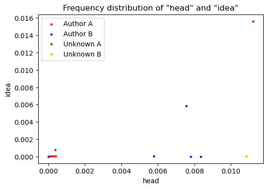

```python
fig, ax = plt.subplots(figsize=(6, 4))
plt.scatter(x[:5], y[:5], s=5, c="r", label="Author A")
plt.scatter(x[5:10], y[5:10], s=5,c="b", label="Author B")
plt.scatter(x[10], y[10], s=5, c="g", label="Unknown A")
plt.scatter(x[11], y[11], s=5, c="y", label="Unknown B")
plt.xlabel(x_word)
plt.ylabel(y_word)
plt.legend(loc="best")
plt.title(f'Frequency distribution of "{x_word}" and "{y_word}"')
plt.show()
```

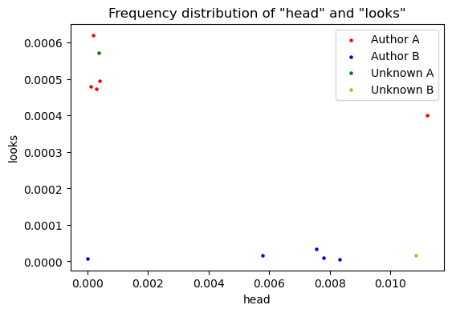

```python
fig, ax = plt.subplots(figsize=(6, 4))
plt.scatter(x[:5], z[:5], s=5, c="r", label="Author A")
plt.scatter(x[5:10], z[5:10], s=5,c="b", label="Author B")
plt.scatter(x[10], z[10], s=5, c="g", label="Unknown A")
plt.scatter(x[11], z[11], s=5, c="y", label="Unknown B")
plt.xlabel(x_word)
plt.ylabel(z_word)
plt.legend(loc="best")
plt.title(f'Frequency distribution of "{x_word}" and "{z_word}"')
plt.show()
```

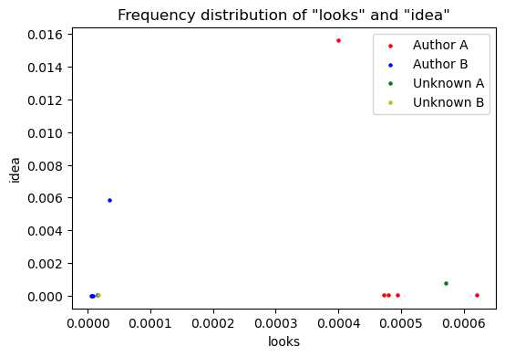

```python
fig, ax = plt.subplots(figsize=(6, 4))
plt.scatter(z[:5], y[:5], s=5, c="r", label="Author A")
plt.scatter(z[5:10], y[5:10], s=5,c="b", label="Author B")
plt.scatter(z[10], y[10], s=5, c="g", label="Unknown A")
plt.scatter(z[11], y[11], s=5, c="y", label="Unknown B")
plt.xlabel(z_word)
plt.ylabel(y_word)
plt.legend(loc="best")
plt.title(f'Frequency distribution of "{z_word}" and "{y_word}"')
plt.show()
```

```python
%matplotlib ipympl
from mpl_toolkits import mplot3d
```

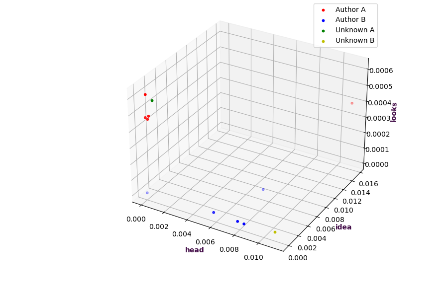

```python
# title = f"Scatter plot showing the distribution between {x_word}, {y_word} and {z_word}."

fig1=plt.figure(figsize=(9,6), dpi=100)
ax = fig1.add_axes([0.1,0.1,0.9,0.9],projection ="3d")

ax.set_xlabel(x_word,c="#420C47",weight="bold")
ax.set_ylabel(y_word,c="#420C47",weight="bold")
ax.set_zlabel(z_word,c="#420C47",weight="bold")
ax.scatter3D(x[:5],y[:5],z[:5], c="r" ,s=10, label="Author A")
ax.scatter3D(x[5:10],y[5:10],z[5:10], c="b" ,s=10, label="Author B")
ax.scatter3D(x[10],y[10],z[10], c="g" ,s=10, label="Unknown A")
ax.scatter3D(x[11],y[11],z[11], c="y" ,s=10, label="Unknown B")
plt.legend(loc="best")
plt.show()
```

## 7. KNN Analysis

Using k values (`k=5` and `k=7`), I will perform a KNN analysis both `Unknown A` and `Unknown B`. I first create a distance function (`d(x,y,z)`) to calculate the 3 dimensional distance between the unknown authors' works and the known. I then append and sort them into a list to get the closests neighbors to the unknown authors (`neighbors(label,x,y,z)`).  
After this, I plot a 3d scatter plot to show the closest k neighbors to the unknown authors.  
**The author with the most neighbors within the range k is considered the author of the unknown work.**

### Unknown A

```python
def d(n,x1,y1,z1):
    return np.sqrt((x[n] - x1)**2 + (y[n] - y1)**2 + (z[n] - z1)**2)

def neighbor(label, x1, y1,z1,n):
    return (d(n,x1,y1,z1), x1, y1, z1, label)
```

```python
neighborsa = [ neighbor("Author A", x[i], y[i], z[i],10) for i in range(5)]
neighborsa += [ neighbor("Author B", x[i], y[i], z[i],10) for i in range(5,10)]
neighborsa.sort()
neighborsa
```

```
[(0.0007607384570271179, 0.000284, 4.7e-05, 0.000473, 'Author A'),
 (0.0007790474953428706, 0.000392, 2.1e-05, 0.000495, 'Author A'),
 (0.0007972772416167415, 0.000184, 2.3e-05, 0.000621, 'Author A'),
 (0.0008227326418709787, 0.000101, 2.5e-05, 0.00048, 'Author A'),
 (0.001037160546877869, 7e-06, 7e-06, 7e-06, 'Author B'),
 (0.005478853986008388, 0.005772, 4.8e-05, 1.6e-05, 'Author B'),
 (0.007487734904495485, 0.007799, 1.9e-05, 9e-06, 'Author B'),
 (0.008019821007977672, 0.008335, 1.9e-05, 6e-06, 'Author B'),
 (0.00879890413631152, 0.007545, 0.005865, 3.5e-05, 'Author B'),
 (0.018379512425524245, 0.011211, 0.015639, 0.0004, 'Author A')]
```

### k = 5

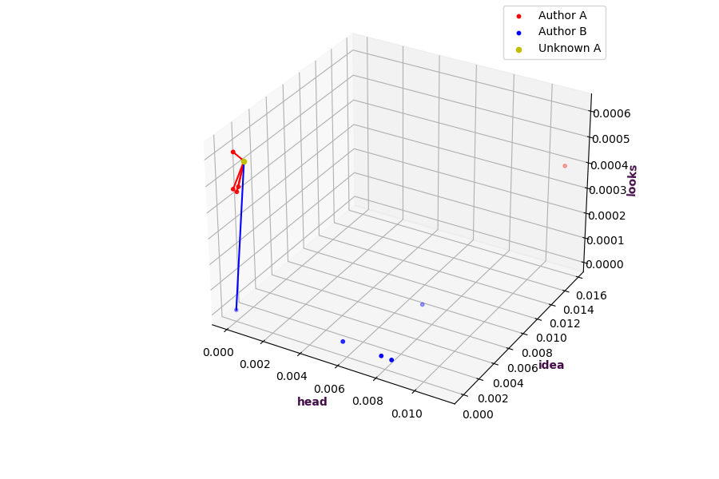

```
Using a value of k=5, we can predict that the Unknown Author  "is Author A"
```

```python
k=5

fig2=plt.figure(figsize=(9,6), dpi=100)
aux =fig2.add_axes([0.1,0.1,0.9,0.9],projection ="3d")
aux.set_xlabel(x_word,c="#420C47",weight="bold")
aux.set_ylabel(y_word,c="#420C47",weight="bold")
aux.set_zlabel(z_word,c="#420C47",weight="bold")
aux.scatter3D(x[:5],y[:5],z[:5], c="r" ,s=10, label="Author A")
aux.scatter3D(x[5:10],y[5:10],z[5:10], c="b" ,s=10, label="Author B")
aux.scatter3D(x[10],y[10],z[10], c="y" ,s=20, label="Unknown A")
plt.legend(loc="best")
counta=0
countb=0
for i in range(k):
    x1 =[x[10],neighborsa[i][1]]
    y1 = [y[10], neighborsa[i][2]]
    z1 = [z[10], neighborsa[i][3]]
    if neighborsa[i][4] == "Author A":
        color = "r"
        counta+=1
    else:
        color = "b"
        countb+=1
    plt.plot(x1, y1,z1, c=color)

plt.show()

if max(counta, countb) ==counta:
    prediction= "is Author A"
elif max(counta, countb) ==countb:
    prediction= "is Author B"
else: prediction = "cannot be determined"

print(f'Using a value of k={k}, we can predict that the Unknown Author  "{prediction}"' )
# print(counta, countb)
```

### k = 7

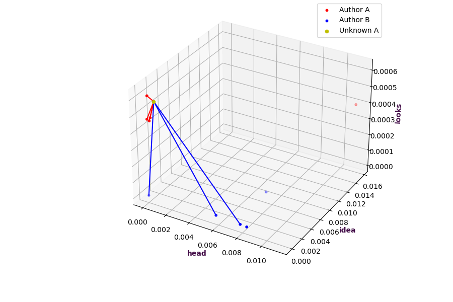

```
Using a value of k=7, we can predict that the Unknown Author "is Author A"
```

```python
k=7

fig3=plt.figure(figsize=(9,6), dpi=100)
aux =fig3.add_axes([0.1,0.1,0.9,0.9],projection ="3d")
aux.set_xlabel(x_word,c="#420C47",weight="bold")
aux.set_ylabel(y_word,c="#420C47",weight="bold")
aux.set_zlabel(z_word,c="#420C47",weight="bold")
aux.scatter3D(x[:5],y[:5],z[:5], c="r" ,s=10, label="Author A")
aux.scatter3D(x[5:10],y[5:10],z[5:10], c="b" ,s=10, label="Author B")
aux.scatter3D(x[10],y[10],z[10], c="y" ,s=20, label="Unknown A")
plt.legend(loc="best")

counta1=0
countb1=0
for i in range(k):
    x1 =[x[10],neighborsa[i][1]]
    y1 = [y[10], neighborsa[i][2]]
    z1 = [z[10], neighborsa[i][3]]
    if neighborsa[i][4] == "Author A":
        color = "r"
        counta1+=1
    else:
        color = "b"
        countb1+=1
    plt.plot(x1, y1,z1, c=color)

plt.show()

if max(counta1, countb1) ==counta1:
    prediction= "is Author A"
elif max(counta1, countb1) ==countb1:
    prediction= "is Author B"
else: prediction = "cannot be determined"

print(f'Using a value of k={k}, we can predict that the Unknown Author "{prediction}"' )
# print(counta, countb)
```

### Unknown B

```python
neighborsb = [ neighbor("Author A", x[i], y[i], z[i],11) for i in range(5)]
neighborsb += [ neighbor("Author B", x[i], y[i], z[i],11) for i in range(5,10)]
neighborsb.sort()
neighborsb
```

```
[(0.0025112409283061625, 0.008335, 1.9e-05, 6e-06, 'Author B'),
 (0.0030471891966203867, 0.007799, 1.9e-05, 9e-06, 'Author B'),
 (0.00507400167520666, 0.005772, 4.8e-05, 1.6e-05, 'Author B'),
 (0.006684900448024638, 0.007545, 0.005865, 3.5e-05, 'Author B'),
 (0.01046496827515497, 0.000392, 2.1e-05, 0.000495, 'Author A'),
 (0.01057184018986288, 0.000284, 4.7e-05, 0.000473, 'Author A'),
 (0.01067913390682971, 0.000184, 2.3e-05, 0.000621, 'Author A'),
 (0.01075500455601949, 0.000101, 2.5e-05, 0.00048, 'Author A'),
 (0.010839098025204864, 7e-06, 7e-06, 7e-06, 'Author B'),
 (0.015595976500367011, 0.011211, 0.015639, 0.0004, 'Author A')]
```

### k = 5

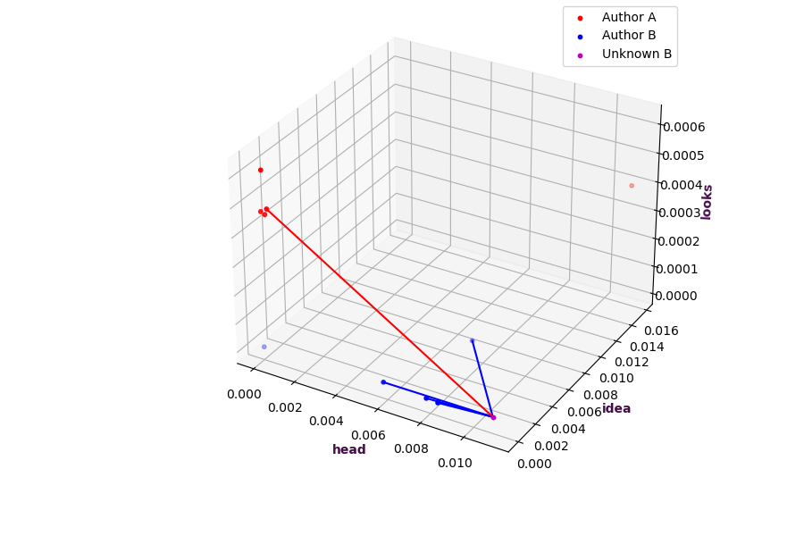

```
Using a value of k=5, we can predict that the Unknown Author "is Author B"
```

```python
k=5

fig4=plt.figure(figsize=(9,6), dpi=100)
aux =fig4.add_axes([0.1,0.1,0.9,0.9],projection ="3d")
aux.set_xlabel(x_word,c="#420C47",weight="bold")
aux.set_ylabel(y_word,c="#420C47", weight="bold")
aux.set_zlabel(z_word,c="#420C47",weight="bold")
aux.scatter3D(x[:5],y[:5],z[:5], c="r" ,s=10, label="Author A")
aux.scatter3D(x[5:10],y[5:10],z[5:10], c="b" ,s=10, label="Author B")
aux.scatter3D(x[11],y[11],z[11], c="m" ,s=10, label="Unknown B")
plt.legend(loc="best")
count1a=0
count1b=0
for i in range(k):
    x1b =[x[11],neighborsb[i][1]]
    y1b = [y[11], neighborsb[i][2]]
    z1b = [z[11], neighborsb[i][3]]
    if neighborsb[i][4] == "Author A":
        color = "r"
        count1a+=1
    else:
        color = "b"
        count1b+=1
    plt.plot(x1b, y1b,z1b, c=color)

plt.show()

if max(count1a, count1b) ==count1a:
    prediction= "is Author A"
elif max(count1a, count1b) ==count1b:
    prediction= "is Author B"
else: prediction = "cannot be determined"

print(f'Using a value of k={k}, we can predict that the Unknown Author "{prediction}"' )
# print(count1a, count1b)
```

### k = 7

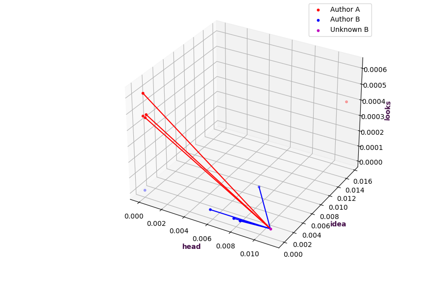

```
Using a value of k=7, we can predict that the Unknown Author "is Author B"
```

```python
k=7

fig4=plt.figure(figsize=(9,6), dpi=100)
aux =fig4.add_axes([0.1,0.1,0.9,0.9],projection ="3d")
aux.set_xlabel(x_word,c="#420C47",weight="bold")
aux.set_ylabel(y_word,c="#420C47",weight="bold")
aux.set_zlabel(z_word,c="#420C47",weight="bold")
aux.scatter3D(x[:5],y[:5],z[:5], c="r" ,s=10, label="Author A")
aux.scatter3D(x[5:10],y[5:10],z[5:10], c="b" ,s=10, label="Author B")
aux.scatter3D(x[11],y[11],z[11], c="m" ,s=10, label="Unknown B")
plt.legend(loc="best")
count1a=0
count1b=0
for i in range(k):
    x1b =[x[11],neighborsb[i][1]]
    y1b = [y[11], neighborsb[i][2]]
    z1b = [z[11], neighborsb[i][3]]
    if neighborsb[i][4] == "Author A":
        color = "r"
        count1a+=1
    else:
        color = "b"
        count1b+=1
    plt.plot(x1b, y1b,z1b, c=color)

plt.show()

if max(count1a, count1b) ==count1a:
    prediction= "is Author A"
elif max(count1a, count1b) ==count1b:
    prediction= "is Author B"
else: prediction = "cannot be determined"

print(f'Using a value of k={k}, we can predict that the Unknown Author "{prediction}"' )
# print(count1a, count1b)
```

## Observation and Conclusion

The KNN classification was used to determine the authors of two literary works (`Unknown A` and `Unknown B`) from sample of five written works each from two known authors.  
From the results, we can conclude that using a k value of `k=5` and `k=7`, **`Author A`** is the author of **`Unknown A`** and **`Author B`** is the author of **`Unknown B`.**